# R Notebook

### 1. Os Dados

```r
users_data_from_github = read_csv(here("data/github-users-committing-filetypes.csv"),
                col_types = cols(
                      .default = col_double(),
                      file_extension = col_character(),
                      month_day = col_integer(),
                      the_month = col_integer(),
                      the_year = col_integer(),
                      users = col_integer()
                    ))

non_programming_languages <- c("pdf", "md", "html", "txt", "json", "xml", "css", "yml", "scss", "jpg",
                   "lock", "png", "gradle", "config", "ico", "gif", "svg", "csproj", "rst",
                   "map", "ttf", "yaml", "pbxproj", "less", "woff", "eot")

programming_languages <- subset(users_data_from_github, !(file_extension %in% non_programming_languages))

programming_languages_sorted <- programming_languages %>%
  arrange(file_extension, the_year, the_month, month_day)

##Linguagens de programacao
unique(programming_languages_sorted$file_extension)
```

```
##  [1] "c"     "cc"    "cpp"   "cs"    "go"    "h"     "java"  "js"
##  [9] "m"     "php"   "py"    "rb"    "sh"    "sql"   "swift" "ts"
```

```r
programming_languages_sorted <- programming_languages_sorted %>%
  mutate(date_formated = paste(the_year, the_month, month_day, sep="-")) %>%
  mutate(is_weekend = is.weekend(date_formated))
```

### 2. Popularidade nas amostras das linguagens escolhidas

Os dados colhidos tem queda de popularidade das duas linguagens durante as ferias americanas (summer vacation). Neste periodo quase todos os estudantes tem uma produtividade reduzida, isso foi refletido na queda acentuada da popularidade das linguagens go e java script.

É possivel que esses dados nao contenham informaçoes sobre popularidade de linguagens em empresas, pois o esperado é que a quantidade de commits nao caiam tao acentuadamente durante o summer vacation.

#### 2.2 JavaScript

```r
js <- programming_languages_sorted %>%
  filter(file_extension == "js") %>%
  group_by(file_extension, the_year, the_month) %>%
  summarise(monthly_users = sum(users))


year <- as.factor(js$the_year)
sp <- ggplot(js, aes(x = the_month,y = monthly_users, color = year)) +
    geom_point(size=1) + xlab("Month") + ylab("Users") +
    geom_line() +
    ggtitle("Java Script") +
    geom_hline(aes(yintercept=median(monthly_users)),colour="#315b7d", linetype="dashed")

#sp <- sp + facet_grid(rows = vars(js$the_year)) + theme(legend.position="none")

ggplotly(sp)
```

```
## We recommend that you use the dev version of ggplot2 with `ggplotly()`
## Install it with: `devtools::install_github('hadley/ggplot2')`
```

[interactive chart not shown]

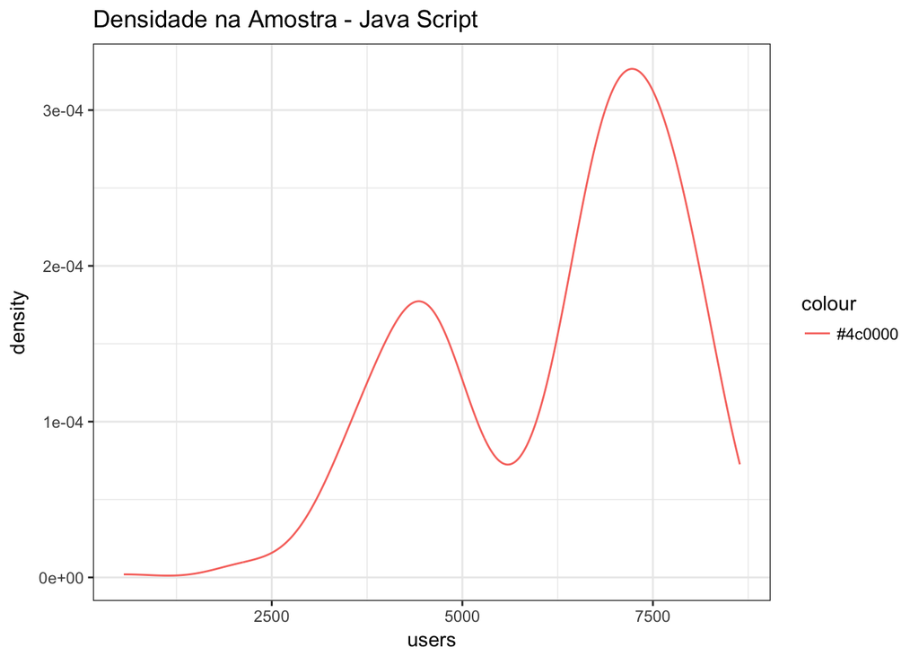

```r
js <- programming_languages_sorted %>%
  filter(file_extension == "js")

js %>%
  ggplot(aes(x = users)) +
  stat_density(aes(group = file_extension, color = "#4c0000"),position="identity",geom="line") +
  ggtitle("Densidade na Amostra - Java Script")
```

#### 2.2 Go

```r
go <- programming_languages_sorted %>%
  filter(file_extension == "go") %>%
  group_by(file_extension, the_year, the_month) %>%
  summarise(monthly_users = sum(users))

year <- as.factor(go$the_year)
sp <- ggplot(go, aes(x = the_month,y = monthly_users, color = year)) +
    geom_line() +
    geom_point(size=1) + xlab("Month") + ylab("Users") +
    ggtitle("Go") +
    geom_hline(aes(yintercept=median(monthly_users)),colour="#315b7d", linetype="dashed")

#sp <- sp + facet_grid(rows = vars(the_year)) + theme(legend.position="none")

ggplotly(sp)
```

```
## We recommend that you use the dev version of ggplot2 with `ggplotly()`
## Install it with: `devtools::install_github('hadley/ggplot2')`
```

[interactive chart not shown]

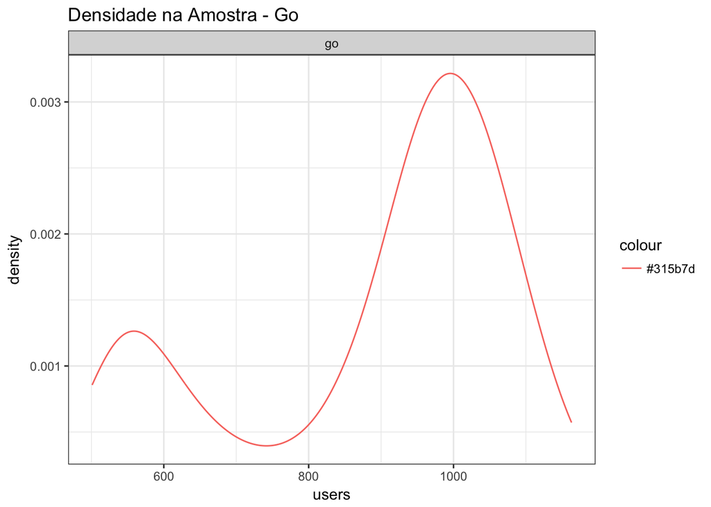

```r
go <- programming_languages_sorted %>%
  filter(file_extension == "go")

go %>%
  ggplot(aes(x = users)) +
  stat_density(aes(group = file_extension, color = "#315b7d"),position="identity",geom="line") +
  facet_wrap(~ file_extension) +
  ggtitle("Densidade na Amostra - Go")
```

### 3.Bootstrap

#### 3.1 Para cada uma delas, há uma diferença significativa na sua popularidade durante a semana e durante o fim de semana? Essa diferença é grande?

##### 3.1.1 JAVA SCRIPT

*Utilizando bootstrap:* Diferença na popularidade da linguagem Java Script durante a semana e o fim de semana.

```r
set.seed(1)

js_weekend <- programming_languages_sorted %>%
  filter(file_extension == "js") %>%
      filter(is_weekend == TRUE)

funcao_bootstrap <- function(dado, indices){
    d = dado %>%
        slice(indices) %>% # slice(x, c(1, 4, 5)) retorna um vetor com os elementos nos índices 1, 4 e 5 de x
        pull(users)         # tempo_no_site é o nome da variável que nos interessa
    return(mean(d))
}

bootstraps <- boot(data = js_weekend,
                   statistic = funcao_bootstrap, # <- referência para a função
                   R = 2000) # número de bootstraps

#glimpse(bootstraps$t)

boot.ci(bootstraps, conf = 0.95, type = "bca")
```

```
## BOOTSTRAP CONFIDENCE INTERVAL CALCULATIONS
## Based on 2000 bootstrap replicates
##
## CALL :
## boot.ci(boot.out = bootstraps, conf = 0.95, type = "bca")
##
## Intervals :
## Level       BCa
## 95%   (4090, 4303 )
## Calculations and Intervals on Original Scale
```

```r
js_weekday <- programming_languages_sorted %>%
  filter(file_extension == "js") %>%
      filter(is_weekend == FALSE)

bootstraps <- boot(data = js_weekday,
                   statistic = funcao_bootstrap, # <- referência para a função
                   R = 2000) # número de bootstraps

boot.ci(bootstraps, conf = 0.95, type = "bca")
```

```
## BOOTSTRAP CONFIDENCE INTERVAL CALCULATIONS
## Based on 2000 bootstrap replicates
##
## CALL :
## boot.ci(boot.out = bootstraps, conf = 0.95, type = "bca")
##
## Intervals :
## Level       BCa
## 95%   (6920, 7133 )
## Calculations and Intervals on Original Scale
```

Como os intervalos sao disjuntos, a linguagem Java Script é em media mais popular durante os dias da semana.

##### 3.1.2 GO

*Utilizando bootstrap:* Diferença na popularidade da linguagem Go durante a semana e o fim de semana.

```r
go_weekend <- programming_languages_sorted %>%
  filter(file_extension == "go") %>%
      filter(is_weekend == TRUE)

funcao_bootstrap <- function(dado, indices){
    d = dado %>%
        slice(indices) %>% # slice(x, c(1, 4, 5)) retorna um vetor com os elementos nos índices 1, 4 e 5 de x
        pull(users)         # tempo_no_site é o nome da variável que nos interessa
    return(mean(d))
}

bootstraps <- boot(data = go_weekend,
                   statistic = funcao_bootstrap, # <- referência para a função
                   R = 2000) # número de bootstraps

boot.ci(bootstraps, conf = 0.95, type = "bca")
```

```
## BOOTSTRAP CONFIDENCE INTERVAL CALCULATIONS
## Based on 2000 bootstrap replicates
##
## CALL :
## boot.ci(boot.out = bootstraps, conf = 0.95, type = "bca")
##
## Intervals :
## Level       BCa
## 95%   (557.5, 575.8 )
## Calculations and Intervals on Original Scale
```

```r
go_weekday <- programming_languages_sorted %>%
  filter(file_extension == "go") %>%
      filter(is_weekend == FALSE)

bootstraps <- boot(data = go_weekday,
                   statistic = funcao_bootstrap, # <- referência para a função
                   R = 2000) # número de bootstraps

boot.ci(bootstraps, conf = 0.95, type = "bca")
```

```
## BOOTSTRAP CONFIDENCE INTERVAL CALCULATIONS
## Based on 2000 bootstrap replicates
##
## CALL :
## boot.ci(boot.out = bootstraps, conf = 0.95, type = "bca")
##
## Intervals :
## Level       BCa
## 95%   (958.5, 981.4 )
## Calculations and Intervals on Original Scale
```

Como os intervalos sao disjuntos, a linguagem Go é, em media, mais popular durante os dias da semana.

#### 3.2 Existe uma diferença significativa entre a popularidade das duas linguagens nos fins de semana?

*Media e mediana da amostra:*

```r
amostra <- programming_languages_sorted %>%
  filter(file_extension %in% c("go", "js")) %>%
  group_by(is_weekend) %>%
  select(users, is_weekend) %>%
  summarise_all(funs(mean, median))

amostra
```

[output not shown]

Na amostra, a popularidade das linguagens caem durante o fim de semana.

*Utilizando bootstrap: Media da populacao no fim de semana*

```r
set.seed(1)

amostra_weekend <- programming_languages_sorted %>%
  filter(file_extension %in% c("js", "go")) %>%
  filter(is_weekend == TRUE)

funcao_bootstrap <- function(dado, indices){
    d = dado %>%
        slice(indices) %>% # slice(x, c(1, 4, 5)) retorna um vetor com os elementos nos índices 1, 4 e 5 de x
        pull(users)         # tempo_no_site é o nome da variável que nos interessa
    return(mean(d))
}

bootstraps <- boot(data = amostra_weekend,
                   statistic = funcao_bootstrap, # <- referência para a função
                   R = 2000) # número de bootstraps

#glimpse(bootstraps$t)

boot.ci(bootstraps, conf = 0.95, type = "bca")
```

```
## BOOTSTRAP CONFIDENCE INTERVAL CALCULATIONS
## Based on 2000 bootstrap replicates
##
## CALL :
## boot.ci(boot.out = bootstraps, conf = 0.95, type = "bca")
##
## Intervals :
## Level       BCa
## 95%   (2546, 3031 )
## Calculations and Intervals on Original Scale
```

*Utilizando bootstrap: Media da populacao nos dias uteis*

```r
amostra_weekday <- programming_languages_sorted %>%
  filter(file_extension %in% c("js", "go")) %>%
  filter(is_weekend == FALSE)

bootstraps <- boot(data = amostra_weekday,
                   statistic = funcao_bootstrap, # <- referência para a função
                   R = 2000) # número de bootstraps

#glimpse(bootstraps$t)

boot.ci(bootstraps, conf = 0.95, type = "bca")
```

```
## BOOTSTRAP CONFIDENCE INTERVAL CALCULATIONS
## Based on 2000 bootstrap replicates
##
## CALL :
## boot.ci(boot.out = bootstraps, conf = 0.95, type = "bca")
##
## Intervals :
## Level       BCa
## 95%   (3767, 4240 )
## Calculations and Intervals on Original Scale
```

Como os dois intervalos sao disjuntos, podemos concluir que as linguagens escolhidas, em media, sao mais populares durante dias de semana.

#### 3.3 Ha diferenca entre a popularidade sexta e sabado?

Utilizando as duas linguagens escolhidas.

```r
amostra <- programming_languages_sorted %>%
  mutate(day_of_week = day.of.week(the_year, the_month, month_day))

sexta <- amostra %>%
  filter(file_extension %in% c("js", "go")) %>%
  filter(day_of_week == 5)

sabado <- amostra %>%
  filter(file_extension %in% c("js", "go")) %>%
  filter(day_of_week == 6)


bootstraps_sexta <- boot(data = sexta,
                   statistic = funcao_bootstrap, # <- referência para a função
                   R = 2000) # número de bootstraps

bootstraps_sabado <- boot(data = sabado,
                   statistic = funcao_bootstrap, # <- referência para a função
                   R = 2000) # número de bootstraps

boot.ci(bootstraps_sexta, conf = 0.95, type = "bca")
```

```
## BOOTSTRAP CONFIDENCE INTERVAL CALCULATIONS
## Based on 2000 bootstrap replicates
##
## CALL :
## boot.ci(boot.out = bootstraps_sexta, conf = 0.95, type = "bca")
##
## Intervals :
## Level       BCa
## 95%   (3180, 4137 )
## Calculations and Intervals on Original Scale
```

```r
boot.ci(bootstraps_sabado, conf = 0.95, type = "bca")
```

```
## BOOTSTRAP CONFIDENCE INTERVAL CALCULATIONS
## Based on 2000 bootstrap replicates
##
## CALL :
## boot.ci(boot.out = bootstraps_sabado, conf = 0.95, type = "bca")
##
## Intervals :
## Level       BCa
## 95%   (3235, 4243 )
## Calculations and Intervals on Original Scale
```

#### 3.4 Ha dirença substancial entre segunda e domingo?

Utilizando as duas linguagens escolhidas.

```r
segunda <- amostra %>%
  filter(file_extension %in% c("js", "go")) %>%
  filter(day_of_week == 1)

domingo <- amostra %>%
  filter(file_extension %in% c("js", "go")) %>%
  filter(day_of_week == 0)


bootstraps_segunda <- boot(data = segunda,
                   statistic = funcao_bootstrap, # <- referência para a função
                   R = 2000) # número de bootstraps

bootstraps_domingo <- boot(data = domingo,
                   statistic = funcao_bootstrap, # <- referência para a função
                   R = 2000) # número de bootstraps

boot.ci(bootstraps_segunda, conf = 0.95, type = "bca")
```

```
## BOOTSTRAP CONFIDENCE INTERVAL CALCULATIONS
## Based on 2000 bootstrap replicates
##
## CALL :
## boot.ci(boot.out = bootstraps_segunda, conf = 0.95, type = "bca")
##
## Intervals :
## Level       BCa
## 95%   (3214, 4218 )
## Calculations and Intervals on Original Scale
```

```r
boot.ci(bootstraps_domingo, conf = 0.95, type = "bca")
```

```
## BOOTSTRAP CONFIDENCE INTERVAL CALCULATIONS
## Based on 2000 bootstrap replicates
##
## CALL :
## boot.ci(boot.out = bootstraps_domingo, conf = 0.95, type = "bca")
##
## Intervals :
## Level       BCa
## 95%   (3229, 4226 )
## Calculations and Intervals on Original Scale
```